# Data analysis with PRI - Pattern Recognition with Immune cells

Yen Hoang & Ines Hoppe

11/30/2021

## Data description

The two files we use in this tutorial are part of a re-analysis perfomed for 13 blood samples using PRI. These samples were taken from a publicly available dataset and can be downloaded from [Cytobank](https://www.cytobank.org/nolanlab/reports/Spitzer2017.html). Compensation, elimination of doublets and dead cells was done in [FlowJo](http://flowjo.com), as well as gating on CD4<sup>+</sup> T cells resulting in the files as they are provided in the ‘data’ folder.

For comparability of the re-analysis results with the original results we used a gating strategy similar to that in the [study](https://www.sciencedirect.com/science/article/pii/S009286741631738X?via%3Dihub) we aim to compare our results with.

## Example analysis with PRI - Pattern Recognition with Immune cells

We have selected two files to demonstrate how we create binplots using the PRI approach. We operated on [R version 3.6.1](http://www.r-project.org) running under Windows 10 (64-bit). Help and plot functions use R core functionalities. These functions are accumulated in ‘binplot.R’.

### Load library

First, the ‘flowCore’ library is loaded and the file containing the PRI functions is sourced. If you did not install ‘flowCore’ yet please follow the instructions given under prerequisites from [here](https://github.com/InesHo/PRI-demonstration).

```r
library(flowCore)
source("../code/binplot.R")
```

## 1 General Example for Usage of PRI

This first section in the tutorial demonstrates briefly the general steps of data preparation and visualisation using the file “CD4_TIN_BLD1_Untreated_Day3.fcs”.

### 1.1 Data Preparation

We read in the file using ‘flowCore’. Then we map aliases of markers of interest to the channel names to use them as column names in the data frame we create for the raw data. The data is then transformed with inverse hyperbolic sine (asinh). This is a common transformation method for flow cytometry data ([Finak et. al., 2010](https://link.springer.com/article/10.1186/1471-2105-11-546)).

```r
####### READ IN TREATED SAMPLE
path.folder <- "../data/"
file.untr <- "CD4_TIN_BLD1_Untreated_Day3.fcs"
data.untr <- read.FCS(file=file.path(path.folder,file.untr),which.lines=1)
keys.untr <- keyword(data.untr)
aliases <- unlist(keyword(data.untr, c("$P5S","$P10S","$P28S","$P29S","$P33S")))
channels <- unlist(keyword(data.untr,c("$P5N","$P10N","$P28N","$P29N","$P33N")))
map.untr <- data.frame(alias = aliases, channels = channels)

# load data
exprs.untr <- as.data.frame(exprs(read.FCS(file=file.path(path.folder,file.untr),
                                        channel_alias = map.untr, transformation=NULL)))
# rename column names for channels we are interested in
for ( i in 1:ncol(exprs.untr)) {
  colnames(exprs.untr)[i] = strsplit(colnames(exprs.untr)[i]," ")[[1]][1]
}
# transform data with asinh()
exprs.untr <- asinh(exprs.untr)
```

### 1.2 Data Visualization Using The Binplot

In a binplot, we present two markers X and Y in a bin-based approach on the x and y axis together with a color-coded third feature. The third feature can be used to display a variety of options, like the cell density or information about a third marker, referred to as marker Z.

To do so, the area of the markers X versus Y is categorized into bins of size 0.2 x 0.2. Each bin contains several cells. For these bins we calculate metrics that we plot in a color-coded manner similar to a heatmap. Low values are represented by blues, median values by yellows and high values by shades of red.

The plot created with the code chunk below uses CD90 as X-parameter, CD44 as Y-parameter and CD27 as Z-parameter. As thrird feature, the mean fluorescense intensity of CD27<sup>+</sup> cells (MFI<sup>+</sup>) was calculated.

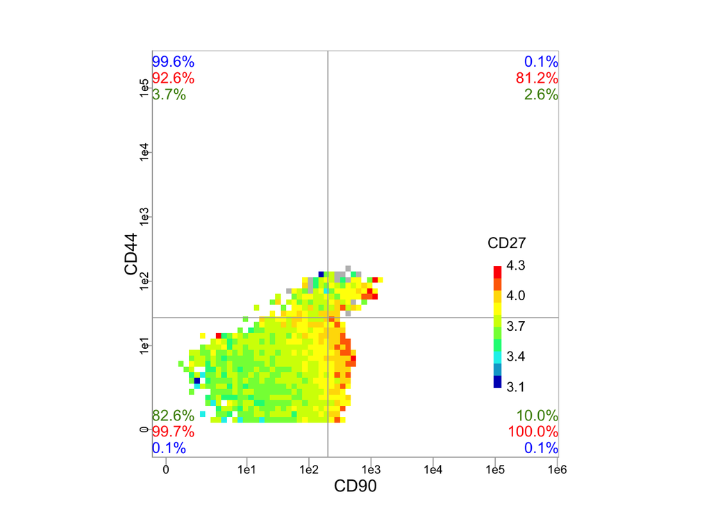

```r
### INITIATING PARAMETERS
featX = "CD90"
featY = "CD44"
featZ1 = "CD27"
cutoffs.man = c(6,4,2)
binSize = 0.2

### PLOTTING PARAMETERS
par(mfrow = c(1,1),
    cex.lab = 1.4, cex.axis = 1.4,
    pin = c(4,4),
    mgp = c(2.0, 0, 0))

### CALL PLOT FUNCTIONS
binplot_table(
  data = exprs.untr,
  feat.X = featX,
  feat.Y = featY,
  feat.Z1 = featZ1,
  calc = "MFI+",
  binsize = binSize,
  cutoffs = cutoffs.man,
  plot.range=c(0.05,12,0.05,12)
)
```

## 2 Use of PRI to Identify Differing Activation Patterns

The second section of this tutorial demonstrates how PRI can reveal differing activation patterns between blood samples coming from a common mouse cancer model being objective to effective and ineffective treatments.

### 2.1 Data Preparation

The files used in this demonstration represent blood cells taken on day three of the experiment. We here again use the file “CD4_TIN_BLD1_Untreated_Day3.fcs” as untreated sample. After preprocession of the raw data file 44083 cells remain. We additionally use the file “CD4_TIN_BLD2_B6Antibodies_Day3.fcs” as an effectively treated example. It has 22679 cells after preprocession.

Since we already prepared and loaded the untreated sample, we only need to load and prepare the treated example at this point. This is done in the some way as it was done in 1.1 for the untreated file. The expression data is also transformed using asinh.

```r
####### READ IN TREATED SAMPLE
file.b6ab <- "CD4_TIN_BLD2_B6Antibodies_Day3.fcs"
data.b6ab <- read.FCS(file=file.path(path.folder,file.b6ab),which.lines=1)
keys.b6ab <- keyword(data.b6ab)
aliases.b6ab <- unlist(keyword(data.b6ab,c("$P5S","$P10S","$P28S","$P29S","$P33S")))
channels.b6ab <- unlist(keyword(data.b6ab,c("$P5N","$P10N","$P28N","$P29N","$P33N")))
map.b6ab <- data.frame(alias = aliases.b6ab, channels = channels.b6ab)

# load data
exprs.b6ab <- as.data.frame(exprs(read.FCS(file=file.path(path.folder,file.b6ab),
                                         channel_alias = map.b6ab, transformation=NULL)))
# rename column names for channels we are interested in
for ( i in 1:ncol(exprs.b6ab)) {
  colnames(exprs.b6ab)[i] = strsplit(colnames(exprs.b6ab)[i]," ")[[1]][1]
}
# transform data with asinh()
exprs.b6ab <- asinh(exprs.b6ab)
```

### 2.2 Binplots Visualizing MFI<sup>+</sup> of CD27 for T-cells From Blood Samples

The range of parameter X (CD90) and parameter Y (CD44) on x and y axis, respectively, is categorized into bins of size 0.2 x 0.2. Here, we used the mean fluorescence intensity of parameter Z<sup>+</sup> cells (MFI<sup>+</sup>) as third feature in the binplots. Moreover, the bins are divided into four quadrants using thresholds for CD90 and CD44.

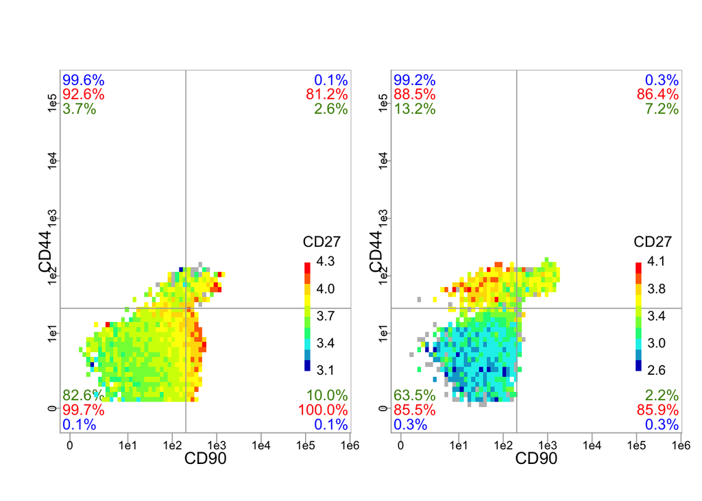

```r
### INITIATING PARAMETERS
featX = "CD90"
featY = "CD44"
featZ1 = "CD27"
cutoffs.man = c(6,4,2)
binSize = 0.2

### PLOTTING PARAMETERS FOR TWO PLOTS
par(mfrow = c(1,2),
    cex.lab = 1.4, cex.axis = 1.4,
    mgp = c(2.0, 0, 0),
    mar = c(2.4,2,2.5,0),
    oma = c(1,1,1,1))

### CALL PLOT FUNCTIONS
binplot_table(
  data = exprs.untr,
  feat.X = featX,
  feat.Y = featY,
  feat.Z1 = featZ1,
  calc = "MFI+",
  binsize = binSize,
  cutoffs = cutoffs.man,
  plot.range=c(0.05,12,0.05,12)
)

binplot_table(
  data = exprs.b6ab,
  feat.X = featX,
  feat.Y = featY,
  feat.Z1 = featZ1,
  calc = "MFI+",
  binsize = binSize,
  cutoffs = cutoffs.man,
  plot.range=c(0.05,12,0.05,12)
)
```

### 2.3 Binplots For Cell Characterisation in Treated Blood Sample using T.bet and Foxp3

To further characterize the cell subpopulations in the treated example we additionally analyzed binplots using T.bet (left figure) and Foxp3 (right figure) respectively as Z parameter.

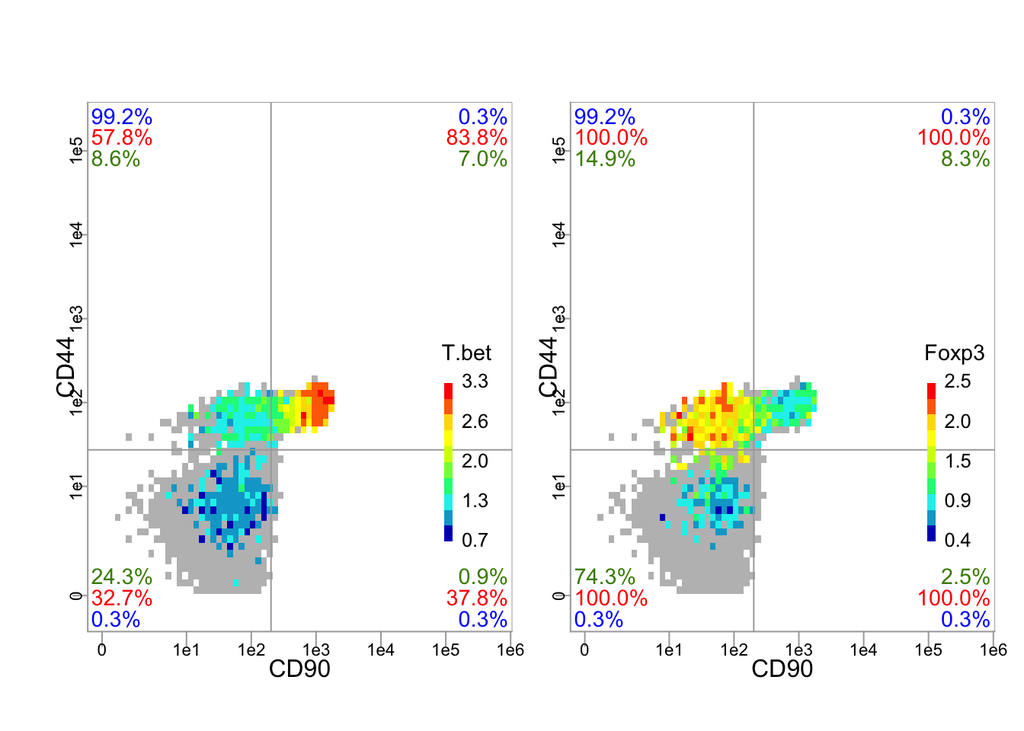

```r
### PLOTTING PARAMETERS FOR TWO PLOTS
par(mfrow = c(1,2),
    cex.lab = 1.4, cex.axis = 1.4,
    mgp = c(2.0, 0, 0),
    mar = c(2.4,2,2.5,0),
    oma = c(1,1,1,1))

### CALL PLOT FUNCTIONS
binplot_table(
  data = exprs.b6ab,
  feat.X = featX,
  feat.Y = featY,
  feat.Z1 = "T.bet",
  calc = "MFI+",
  binsize = binSize,
  cutoffs = c(6,4,0.4),
  plot.range=c(0.05,12,0.05,12)
)

binplot_table(
  data = exprs.b6ab,
  feat.X = featX,
  feat.Y = featY,
  feat.Z1 = "Foxp3",
  calc = "MFI+",
  binsize = binSize,
  cutoffs = c(6,4,0),
  plot.range=c(0.05,12,0.05,12)
)
```